# Análisis de Correspondencias Múltiples

Equipo - 7

2017-04-09

## Análisis de correspondencias múltiples

ACM puede ser visto como una extensión del análisis de correspondencias simple (AC) para un conjunto grande de variables categóricas. Supongamos que la matriz de datos categóricos es $NxQ$ es decir, $N$ individuos y $Q$ variables, el análisis de correspondencias múltiple (ACM) tiene 2 versiones. En la primera transformamos los casos clasificados por variables en una matriz binaria $Z=[Z_{1},Z_{2},...,Z_{Q}]$ donde $Z_{i}$ es una matriz de $NxJ_{q}$ donde $q={1,2,...,Q}$ tal que
$$z_{ij_{q}} = \left \{ \begin{matrix} 1 & \mbox{si }\mbox{el i-ésimo individuo tiene la categoría j de la variable q}
\\ 0 & \mbox{si }\mbox{el i-ésimo individuo no tiene la categoría j de la variable q}\end{matrix}\right.$$
Si la variable $q-ésima$ tiene $J_{q}$ categorías, esta matriz binaria tendrá $J= \ [ \sum_{q}J_{q} \ ]$ columnas, a partir de $Z$ se puede tomar como tabla de contingencia y aplicar el análisis de correspondencias simple.
$$Z=\left(
\begin{array}{c|ccc}
&1&2\cdots&J_{1}\cdots\cdots&1&2\cdots&J_{q}\\
\hline
I_{1}&1&0\cdots &1\cdots\cdots&0&1\cdots&1\\ I_{2}&0&1\cdots &0\cdots\cdots&1&0\cdots&1\\
\vdots & &\ddots & \ddots & & \ddots\\
I_{N}&0&1\dots &1\cdots\cdots&1&0\cdots&0\\
\end{array}
\right)$$

La segunda versión, consiste en calcular la matriz de Burt $B=Z^{T}Z$ la cual resulta de todas las posibles tablas de contingencia de las $Q$ variables, $B$ se construye por superposición de cajas. En los bloques diagonales aparecen matrices diagonales conteniendo las frecuencias marginales de cada una de las variables analizadas. Fuera de la diagonal aparecen las tablas de contingencia correspondientes a todas las combinaciones 2 a 2 de las variables analizadas.

Por ejemplo:

| Individuos | Género | Años | Ingreso |
| --- | --- | --- | --- |
| 1 | Mujer | 5 | Medio |
| 2 | Mujer | 3 | Alto |
| 3 | Hombre | 4 | Bajo |
| 4 | Mujer | 1 | Bajo |
| 5 | Mujer | 2 | Medio |
| 6 | Hombre | 5 | Alto |
| 7 | Mujer | 2 | Medio |
| 8 | Hombre | 3 | Bajo |
| 9 | Hombre | 1 | Alto |
| 10 | Mujer | 4 | Medio |

A partir de esta tabla se construye la tabla de dummies $Z$:

| Género |  | Años |  |  |  |  | Ingresos |  |  |
| --- | --- | --- | --- | --- | --- | --- | --- | --- | --- |
| Mujer | Hombre | 1 | 2 | 3 | 4 | 5 | Bajo | Medio | Alto |
| 1 | 0 | 0 | 0 | 0 | 0 | 1 | 0 | 1 | 0 |
| 1 | 0 | 0 | 0 | 1 | 0 | 0 | 0 | 0 | 1 |
| 0 | 1 | 0 | 0 | 0 | 1 | 0 | 1 | 0 | 0 |
| 1 | 0 | 1 | 0 | 0 | 0 | 0 | 1 | 0 | 0 |
| 1 | 0 | 0 | 1 | 0 | 0 | 0 | 0 | 1 | 0 |
| 0 | 1 | 0 | 0 | 0 | 0 | 1 | 0 | 0 | 1 |
| 1 | 0 | 0 | 1 | 0 | 0 | 0 | 0 | 1 | 0 |
| 0 | 1 | 0 | 0 | 1 | 0 | 0 | 1 | 0 | 0 |
| 0 | 1 | 1 | 0 | 0 | 0 | 0 | 0 | 0 | 1 |
| 1 | 0 | 0 | 0 | 0 | 1 | 0 | 0 | 1 | 0 |

En la tabla disyuntiva completa (matriz $Z$), si hay alguna variable continua, debe transformarse en nominal, ordenándose en intervalos a los que se da un rango de valores.

Las frecuencias marginales de las líneas de la tabla disyuntiva completa son iguales al número de variables ($Q$), y las frecuencias marginales de las columnas corresponden al número de individuos que han elegido la categoría ($j$) de la variable ($q$), por lo que para cada submatriz, el número total de individuos es $N$.

$$Z=\left(
\begin{array}{c|ccc}
&M&H\ &&1&2&3&4&5\ &&B&M&A\\
\hline
I_{1}&1&0\ &&0&0&0&0&1\ &&0&1&0\\ I_{2}&1&0\ &&0&0&1&0&0\ &&0&0&1\\
\ & &\ & \\
I_{3}&0&1\ &&0&0&0&1&0\ &&1&0&0\\
I_{4}&1&0\ &&1&0&0&0&0\ &&1&0&0\\
I_{5}&1&0\ &&0&1&0&0&0\ &&0&1&0\\
I_{6}&0&1\ &&0&0&0&0&1\ &&0&0&1\\
I_{7}&1&0\ &&0&1&0&0&0\ &&0&1&0\\
\ & &\ & \\
I_{8}&0&1\ &&0&0&1&0&0\ &&1&0&0\\
I_{9}&0&1\ &&1&0&0&0&0\ &&0&0&1\\
I_{10}&1&0\ &&0&0&0&1&0\ &&0&1&0\\
\end{array}
\right)$$
La matriz $Z$ está dividida por las variables dummies de las 3 categorías, Género(M,H), Años(1,..5) e Ingresos(B,M,A).

Relacionando cada variable con todas las demás, la tabla disyuntiva se convierte en una tabla de Burt que contiene todas las tablas de contingencia simples entre las variables (cruzadas dos a dos). A partir de la tabla disyuntiva completa se puede construir la tabla de contingencia de Burt ($B$), que es una tabla simétrica de orden $JxJ: B = Z^{T}Z$

$B$ es una conjunción de tablas de contingencia y está formada de $Q^2$ bloques y cada bloque es una submatriz formada por tablas de contingencia de las variables dos a dos, salvo los bloques que están en la diagonal que son las tablas de contingencia de cada variable consigo misma. Con lo cual la matriz de Burt es :

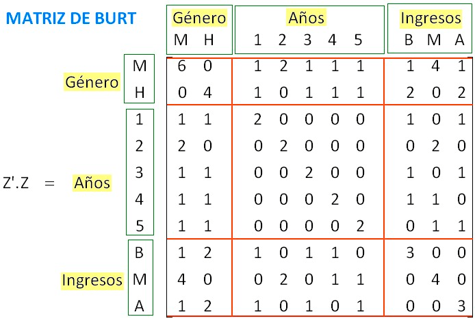

Una propiedad que se cumple para la extensión del ACS en ACM: es equivalente un ACS de la tabla de contingencia entre $Y$ y $X$ que analizar la tabla disyuntiva $Z$ (de $N$ filas e $J$ columnas) o analizar la tabla de Burt de $J$ filas y $J$ columnas

La tabla disyuntiva completa es equivalente a la tabla de Burt y ambos producen los mismos factores.

**Inercias de $Z$.**

Para la matriz $Z$ tenemos que la matriz de probabilidades es $P=\frac{Z}{NN}$ donde $NN=\sum_{ik}z_{ik}$, y sea $r$ el vector de totales por renglones tal que $r=Z1$ donde $1$ es el vector de 1’s, y sea $c$ el vector de totales por columna y sea $D_{c}=diag(c)$ y $D_{r}=diag(r)$ los factores o scores en este caso se obtienen de la descomposición en valores singulares de la matriz:
$$D_{r}^{-\frac{1}{2}}(P-rc^{T})D_{c}^{-\frac{1}{2}}=U\Delta V^{T}$$
con $\Delta$ la matriz diagonal de los valores singulares y $\Lambda=\Delta^{2}$ es la matriz d eigenvalores. Por tanto los scores de los reglones y las columnas son:
$$F=D_{r}^{-\frac{1}{2}}U\Delta\ y\ G=D_{c}^{-\frac{1}{2}}V\Delta$$
**Inercias de la tabla de Burt**

Análogamente para la matriz de Burt $B$ tenemos $P=\frac{B}{\sum_{ij}b_{ij}}$. Como en la tabla de Burt las filas y las columnas representan las mismas categorías, el estudio de ambas ofrecen los mismos resultados, lo único a ajustar son los eigenvalores de $B$ que cumplen la siguiente realción con los eigenvalores de $Z$:
$$\lambda_{B}=\lambda_{Z}^{2}$$
Al igual que en ACS podemos ver los factores por variable y la finalidad es poder pintarlos juntos para hacer una interpretación de todas las categorías.

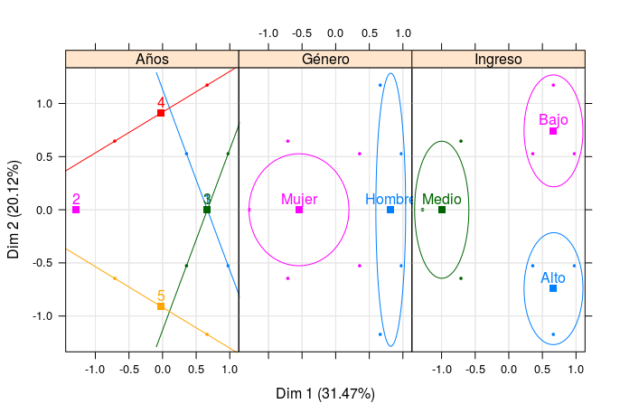

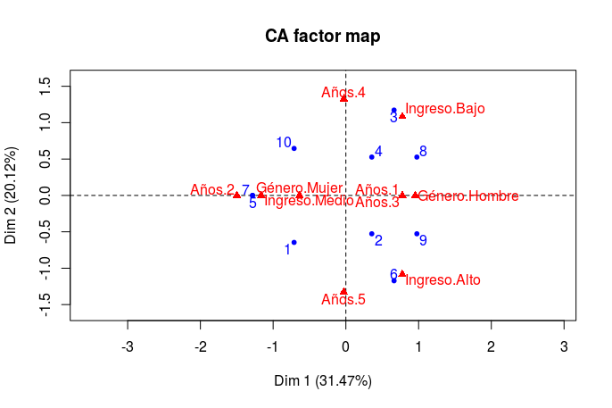

Interpretación de ACM:

1. Dos individuos están próximos si han elegido globalmente las mismas categorías
2. Dos categorías están próximas si han sido elegidas globalmente por el mismo conjunto de individuos.
3. La interpretación de los factores se hace teniendo en cuenta las contribuciones totales de cada variable.

## Ejemplo: dataset de STUDENT

### Librerias utilizadas

```r
# Cargamos paquetes
library(metodosMultivariados2017)
library("FactoMineR")
library("factoextra")
library("gplots")
```

## El Dataset

En este ejemplo examinamos cuales pueden ser las causas probables que afectan o se relacionan con el desempeño de los estudiantes. También buscamos entender qué otras características pueden estar relacionadas a las calificaciones de los estudiantes. Las variables a usar son las siguientes:

```r
# Cargamos data set
data(STUDENT)
MyData <- STUDENT
MyData <- (MyData)[,1:13]
```

## Le echamos un ojo a los datos

```r
# Revisamos datos
head(MyData)
```

```
##   sex address famsize Pstatus      Medu      Fedu guardian schoolsup
## 1   F       U     GT3       A    higher    higher   mother       yes
## 2   F       U     GT3       T   primary   primary   father        no
## 3   F       U     LE3       T   primary   primary   mother       yes
## 4   F       U     GT3       T    higher    medium   mother        no
## 5   F       U     GT3       T secondary secondary   father        no
## 6   M       U     LE3       T    higher secondary   mother        no
##   famsup paid activities higher internet
## 1     no   no         no    yes       no
## 2    yes   no         no    yes      yes
## 3     no  yes         no    yes      yes
## 4    yes  yes        yes    yes      yes
## 5    yes  yes         no    yes       no
## 6    yes  yes        yes    yes      yes
```

```r
summary(MyData)
```

```
##  sex     address famsize   Pstatus        Medu            Fedu
##  F:591   R:285   GT3:738   A:121   higher   :306   higher   :224
##  M:453   U:759   LE3:306   T:923   medium   :289   medium   :324
##                                    none     :  9   none     :  9
##                                    primary  :202   primary  :256
##                                    secondary:238   secondary:231
##    guardian   schoolsup famsup     paid     activities higher    internet
##  father:243   no :925   no :404   no :824   no :528    no : 89   no :217
##  mother:728   yes:119   yes:640   yes:220   yes:516    yes:955   yes:827
##  other : 73
##
##
```

### Numero de categorias por variable

```r
cats = apply(MyData, 2, function(x) nlevels(as.factor(x)))
cats
```

```
##        sex    address    famsize    Pstatus       Medu       Fedu
##          2          2          2          2          5          5
##   guardian  schoolsup     famsup       paid activities     higher
##          3          2          2          2          2          2
##   internet
##          2
```

### Aplicamos el MCA con FactoMineR e imprimimos los eigenvalores

```r
# MCA
mca1 = MCA(MyData, graph = FALSE)

# Tabla de eigenvalores y % de varianza
mca1$eig
```

```
##        eigenvalue percentage of variance cumulative percentage of variance
## dim 1  0.16436057              10.683437                          10.68344
## dim 2  0.10583521               6.879289                          17.56273
## dim 3  0.10388335               6.752418                          24.31514
## dim 4  0.10038735               6.525178                          30.84032
## dim 5  0.09582522               6.228639                          37.06896
## dim 6  0.08722902               5.669886                          42.73885
## dim 7  0.08606152               5.593999                          48.33285
## dim 8  0.08152283               5.298984                          53.63183
## dim 9  0.08102513               5.266633                          58.89846
## dim 10 0.07275892               4.729330                          63.62779
## dim 11 0.07229019               4.698862                          68.32665
## dim 12 0.06943824               4.513486                          72.84014
## dim 13 0.06406953               4.164519                          77.00466
## dim 14 0.06249656               4.062277                          81.06694
## dim 15 0.05799007               3.769354                          84.83629
## dim 16 0.05728004               3.723202                          88.55949
## dim 17 0.05495818               3.572281                          92.13177
## dim 18 0.05116602               3.325791                          95.45757
## dim 19 0.04486967               2.916529                          98.37409
## dim 20 0.02501393               1.625906                         100.00000
```

Coordenadas de columnas:

```r
head(mca1$var$coord)
```

```
##           Dim 1       Dim 2      Dim 3       Dim 4       Dim 5
## F    0.09270834 -0.46366855 -0.2681659  0.28261877 -0.13394330
## M   -0.12095061  0.60491857  0.3498589 -0.36871456  0.17474721
## R    0.57669422  0.18597665 -0.5107758 -0.03089974 -0.27923310
## U   -0.21654526 -0.06983313  0.1917933  0.01160267  0.10485037
## GT3 -0.03636679 -0.13594281 -0.3422780 -0.15557137  0.08970914
## LE3  0.08770813  0.32786206  0.8254940  0.37520154 -0.21635735
```

Coordenadas de filas:

```r
head(mca1$ind$coord)
```

```
##        Dim 1         Dim 2      Dim 3       Dim 4       Dim 5
## 1 -0.1759116 -0.1427284553  0.1223158  0.86530628 -0.29704117
## 2  0.3452999  0.0003175279 -0.4750954  0.12246746  0.23287978
## 3  0.2934291 -0.0933333800 -0.2294582  0.42738555 -0.06868869
## 4 -0.4648494 -0.1661338195 -0.1800596 -0.06002737 -0.34554151
## 5 -0.1785202 -0.5837337754 -0.2560755 -0.02114301  0.49801087
## 6 -0.6520813  0.2480640753  0.1292469 -0.08467783  0.08638012
```

Graficamos como en clase:

```r
mca1_vars_df = data.frame(mca1$var$coord, Variable = rep(names(cats),
    cats))
mca1_obs_df = data.frame(mca1$ind$coord)
```

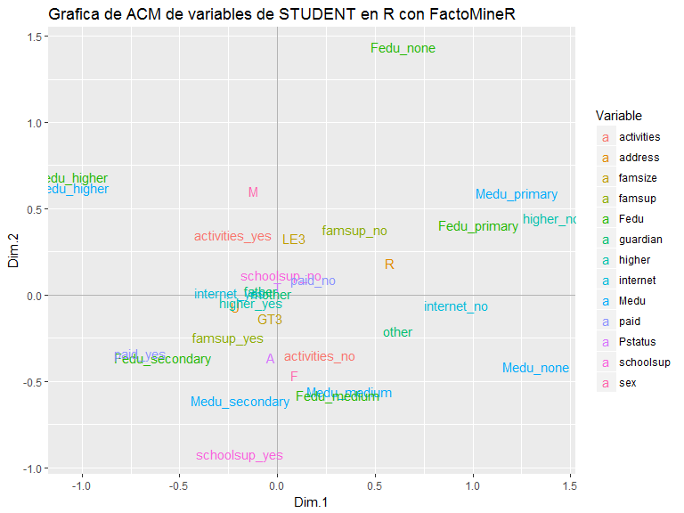

```r
# Grafica de las categorias de las variables
ggplot(data = mca1_vars_df, aes(x = Dim.1, y = Dim.2, label = rownames(mca1_vars_df))) +
    geom_hline(yintercept = 0, colour = "gray70") + geom_vline(xintercept = 0,
    colour = "gray70") + geom_text(aes(colour = Variable)) + ggtitle("Grafica de ACM de variables de STUDENT en R con FactoMineR")
```

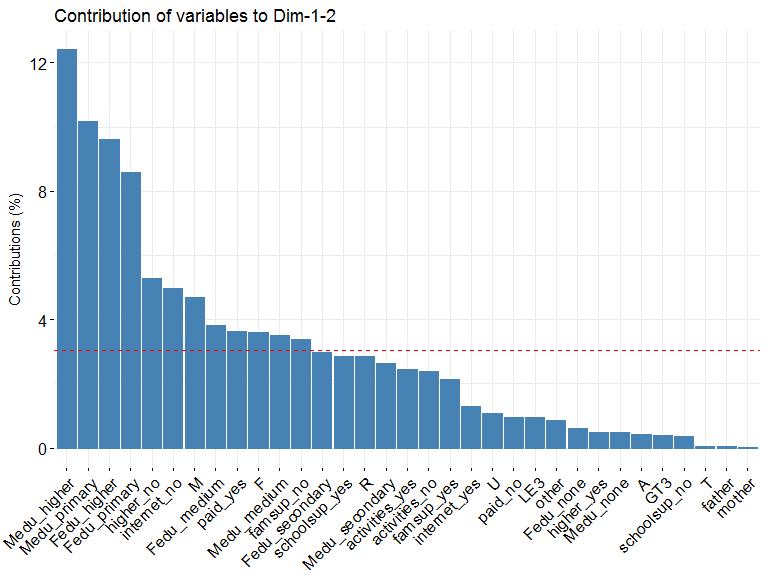

```r
fviz_contrib(mca1, choice ="var", axes = 1:2)
```

Vemos la correlacion de las variables categoricas:

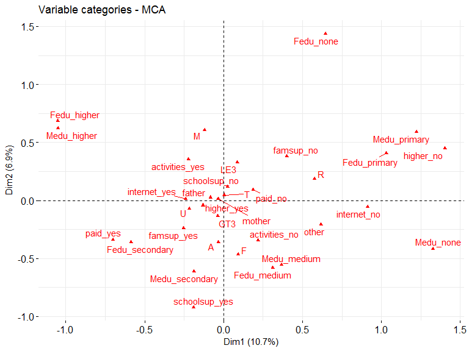

```r
fviz_mca_var(mca1, repel = TRUE)
```

Vemos un biplot de las variables categoricas e ilustramos las que más contribuyen:

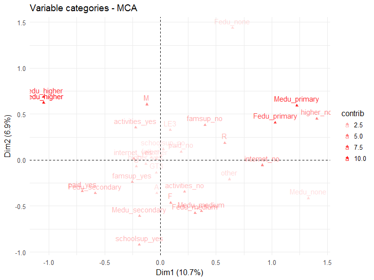

```r
fviz_mca_var(mca1, alpha.var="contrib")+
  theme_minimal()
```

## Haciendo análisis de correspondencias simples (CA)

Primero generamos las funciones que calculan la matriz $Z$ y la matriz de Burt:

```r
dichotom <- function(data,out='numeric') {
  if(!is.data.frame(data)) data <- data.frame(data)
  res <- matrix(nrow=nrow(data),ncol=length(levels(data[,1])))
  for(i in 1:ncol(data)) {
    if(is.factor(data[,i])==FALSE) data[,i] <- factor(data[,i])
    nlevels <- length(levels(data[,i]))
    temp <- matrix(nrow=nrow(data),ncol=nlevels)
    for(j in 1:nlevels) temp[,j] <- ifelse(data[,i]==levels(data[,i])[j],1,0)
    colnames(temp) <- paste(names(data)[i],levels(data[,i]),sep=".")
    if(i==1) res <- temp else res <- cbind(res,temp)
  }
  res <- as.data.frame(res)
  if(out=='factor') for(i in 1:ncol(res)) res[,i] <- as.factor(res[,i])
  res
}

burt <- function(data) {
  disj <- dichotom(data,out='numeric')
  res <- as.matrix(t(disj)) %*% as.matrix(disj)
  return(res)
}
```

Creamos la matriz de 0’s y 1’s a partir de MyData de los datos de STUDENT:

```r
Z<-dichotom(MyData)
head(Z)
```

```
##   sex.F sex.M address.R address.U famsize.GT3 famsize.LE3 Pstatus.A
## 1     1     0         0         1           1           0         1
## 2     1     0         0         1           1           0         0
## 3     1     0         0         1           0           1         0
## 4     1     0         0         1           1           0         0
## 5     1     0         0         1           1           0         0
## 6     0     1         0         1           0           1         0
##   Pstatus.T Medu.higher Medu.medium Medu.none Medu.primary Medu.secondary
## 1         0           1           0         0            0              0
## 2         1           0           0         0            1              0
## 3         1           0           0         0            1              0
## 4         1           1           0         0            0              0
## 5         1           0           0         0            0              1
## 6         1           1           0         0            0              0
##   Fedu.higher Fedu.medium Fedu.none Fedu.primary Fedu.secondary
```

[output cut: 27 more lines]

Hacemos el análisis de correspondencias simples a la matriz $Z$ y graficamos:

```r
res.ca<-CA(Z,graph = FALSE) #corresponcias simples para la matriz Z
res.ca
```

```
## **Results of the Correspondence Analysis (CA)**
## The row variable has  1044  categories; the column variable has 33 categories
## The chi square of independence between the two variables is equal to 20880 (p-value =  1 ).
## *The results are available in the following objects:
##
##    name              description
## 1  "$eig"            "eigenvalues"
## 2  "$col"            "results for the columns"
## 3  "$col$coord"      "coord. for the columns"
## 4  "$col$cos2"       "cos2 for the columns"
## 5  "$col$contrib"    "contributions of the columns"
## 6  "$row"            "results for the rows"
## 7  "$row$coord"      "coord. for the rows"
## 8  "$row$cos2"       "cos2 for the rows"
## 9  "$row$contrib"    "contributions of the rows"
## 10 "$call"           "summary called parameters"
## 11 "$call$marge.col" "weights of the columns"
## 12 "$call$marge.row" "weights of the rows"
```

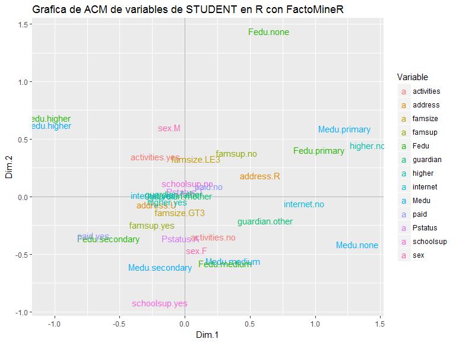

```r
# Graficamos
mca1_vars_df = data.frame(res.ca$col$coord, Variable = rep(names(cats), cats))
mca1_obs_df = data.frame(res.ca$row$coord)

# Grafica de las categorías de las variables
ggplot(data = mca1_vars_df, aes(x = Dim.1, y = Dim.2, label = rownames(mca1_vars_df))) +
    geom_hline(yintercept = 0, colour = "gray70") + geom_vline(xintercept = 0,
    colour = "gray70") + geom_text(aes(colour = Variable)) + ggtitle("Grafica de ACM de variables de STUDENT en R con FactoMineR")
```

Si comparamos la grafica con la obtenida de MCA, es la misma entonces se prueba que ACM es lo mismo que hacer ACS en la matriz $Z$  
Con la matriz de Burt ahora….

```r
B<-burt(MyData)
head(B)
```

```
##             sex.F sex.M address.R address.U famsize.GT3 famsize.LE3
## sex.F         591     0       164       427         440         151
## sex.M           0   453       121       332         298         155
## address.R     164   121       285         0         213          72
## address.U     427   332         0       759         525         234
## famsize.GT3   440   298       213       525         738           0
## famsize.LE3   151   155        72       234           0         306
##             Pstatus.A Pstatus.T Medu.higher Medu.medium Medu.none
## sex.F              77       514         150         179         7
## sex.M              44       409         156         110         2
## address.R          22       263          54          83         2
## address.U          99       660         252         206         7
## famsize.GT3        54       684         214         206         7
## famsize.LE3        67       239          92          83         2
##             Medu.primary Medu.secondary Fedu.higher Fedu.medium Fedu.none
## sex.F                124            131         116         187         3
## sex.M                 78            107         108         137         6
## address.R             86             60          52          94         2
## address.U            116            178         172         230         7
## famsize.GT3          133            178         162         219         8
## famsize.LE3           69             60          62         105         1
##             Fedu.primary Fedu.secondary guardian.father guardian.mother
## sex.F                161            124             128             418
## sex.M                 95            107             115             310
## address.R             95             42              61             203
## address.U            161            189             182             525
## famsize.GT3          173            176             174             510
## famsize.LE3           83             55              69             218
##             guardian.other schoolsup.no schoolsup.yes famsup.no famsup.yes
## sex.F                   45          504            87       194        397
## sex.M                   28          421            32       210        243
## address.R               21          256            29       113        172
## address.U               52          669            90       291        468
## famsize.GT3             54          647            91       270        468
## famsize.LE3             19          278            28       134        172
##             paid.no paid.yes activities.no activities.yes higher.no
## sex.F           466      125           329            262        39
## sex.M           358       95           199            254        50
## address.R       235       50           139            146        34
## address.U       589      170           389            370        55
## famsize.GT3     577      161           371            367        63
## famsize.LE3     247       59           157            149        26
##             higher.yes internet.no internet.yes
## sex.F              552         136          455
## sex.M              403          81          372
## address.R          251          96          189
## address.U          704         121          638
## famsize.GT3        675         155          583
## famsize.LE3        280          62          244
```

Usando correspondencias simples al igual que el ejemplo anterior. Graficamos:

```r
res.ca<-CA(B,graph = FALSE)
res.ca
```

```
## **Results of the Correspondence Analysis (CA)**
## The row variable has  33  categories; the column variable has 33 categories
## The chi square of independence between the two variables is equal to 23777.78 (p-value =  0 ).
## *The results are available in the following objects:
##
##    name              description
## 1  "$eig"            "eigenvalues"
## 2  "$col"            "results for the columns"
## 3  "$col$coord"      "coord. for the columns"
## 4  "$col$cos2"       "cos2 for the columns"
## 5  "$col$contrib"    "contributions of the columns"
## 6  "$row"            "results for the rows"
## 7  "$row$coord"      "coord. for the rows"
## 8  "$row$cos2"       "cos2 for the rows"
## 9  "$row$contrib"    "contributions of the rows"
## 10 "$call"           "summary called parameters"
## 11 "$call$marge.col" "weights of the columns"
## 12 "$call$marge.row" "weights of the rows"
```

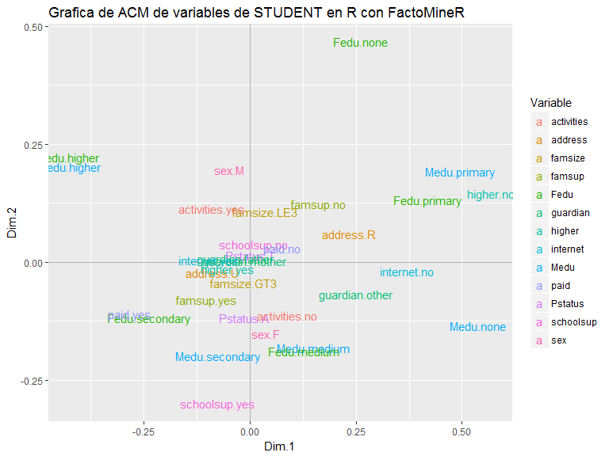

```r
# Graficamos
mca1_vars_df = data.frame(res.ca$col$coord, Variable = rep(names(cats),
    cats))
mca1_obs_df = data.frame(res.ca$row$coord)

# Grafica de las categorias de las variables
ggplot(data = mca1_vars_df, aes(x = Dim.1, y = Dim.2, label = rownames(mca1_vars_df))) +
    geom_hline(yintercept = 0, colour = "gray70") + geom_vline(xintercept = 0,
    colour = "gray70") + geom_text(aes(colour = Variable)) + ggtitle("Grafica de ACM de variables de STUDENT en R con FactoMineR")
```

Se obtiene la misma gráfica, esto comprueba que aplicando un ACS a la matriz de dummies $Z$ y a la matriz de Burt $B$ se llega al mismo resulta que haciendo análisis de correspondencias múltiples a la tabla original MyData.